# Classifying Weight Lifting Excercise Correctness Using Machine Learning

Keh-Harng Feng

April 7, 2017

# 1 Synopsis

Accelerometer data during a weight training exercise is used to build three models using different machine learning algorithms (decision tree, boosted tree and random forest) to classify the correctness of the participants’ motions. Utilizing 10-fold cross-validation, random forest-based model is found to be the best with an out-of-sample accuracy of 99.9%.

# 2 Introduction

Accelerometer sensors attached to six participants recorded data during a weight lifting exercise. Participants carried out the exercise in five different fashions according to instruction: the correct exercise specification and four different, incorrect ways of performing the motion (Velloso et al. 2013).

This reports aims to classify the data into the five classes using different machine learning algorithms and compare their accuracies.

# 3 Data Description

The data is downloaded and loaded into memory using the following code:

```r
if (!file.exists('./pml-training.csv')) {
        download.file(url = 'https://d396qusza40orc.cloudfront.net/predmachlearn/pml-training.csv',
                      destfile = 'pml-training.csv')
    }

    if (!file.exists('./pml-testing.csv')) {
        download.file(url = 'https://d396qusza40orc.cloudfront.net/predmachlearn/pml-testing.csv',
                      destfile = 'pml-testing.csv')
    }

training_raw <- read.csv('pml-training.csv', na.strings = c('#DIV/0!'))

testing_raw <- read.csv('pml-testing.csv', na.strings = c('#DIV/0!'))
```

A summary of the data structure can be seen in the Appendix. There are 160 variables and 19622 observations. The important things to note are

1. The response variable of interest is the `classe` variable in the training set. It specifies the five different motion classes as a five-level factor with levels `A`, `B`, `C`, `D` and `E`. A histogram for their distribution can be seen in Figure 3.1.
2. Certain variables should not have any impact on `classe`. These are `X`, `user_name`, `raw_timestamp_part_1`, `raw_timestamp_part_2` and `cvtd_timestamp`.
3. There are factor variables with massive amount of levels. They are likely misclassified by the `read.csv` routine due to string contaminations. For example, `max_roll_belt` is one of them.
4. There are many variables such as `kurtosis_roll_belt` that are very sparse with mostly just NAs.

The test set contains largely the same information with one crucial difference: there is no `classe` labels. This means it is impossible to use the test set to verify prediction accuracy. As such the analysis will proceed using a `train -> validate -> test` flow. It is explained in more detail in the Data Partition section.

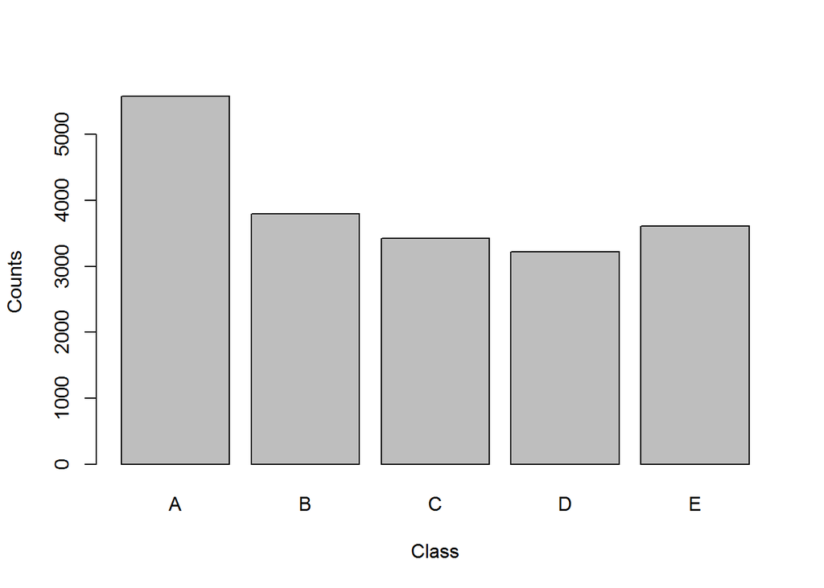

Figure 3.1: Distribution of Classes

## 3.1 Data Preprocessing

The data is first formatted to get rid of all variables that are sparse (ie: over 90% NAs) or do not contribute to the classifications due to its nature (such as `user_name`) and convert erroneous factors using the following code:

```r
# Make copies.
training <- training_raw
testing <- testing_raw

# Data reformat
# Get rid of X, username, timestamps
training <- training[, -c(2,3,4,5)] #Notice that X, the index, is not removed

# column names of those with NA only
sparse_cols <- NULL

# column names of erroneous factors (should be converted to numeric
numeric_cols <- NULL

# Identify cols that contain over 90% NA
# Identify erroneous factors with too many levels to numeric
for (i in 1:length(names(training))) {
    var_name <- names(training)[i]

    if (sum(is.na(training[[var_name]]))/length(training[[var_name]]) > 0.9) {
        sparse_cols <- c(sparse_cols, var_name)
    } else if (class(training[[var_name]]) == 'factor') {
        if (length(levels(training[[var_name]])) > 10) {
            numeric_cols <- c(numeric_cols, var_name)
        }
    }
}

# Get rid of sparse columns
# Convert wrong factors to numeric
training <- training[,!(names(training) %in% sparse_cols)]
testing <- testing[,!(names(testing) %in% sparse_cols)]

for (i in 1:length(numeric_cols)) {
    var_name <- numeric_cols[i]
    training[[var_name]] <- as.numeric(training[[var_name]])
    testing[[var_name]] <- as.numeric(testing[[var_name]])
}
```

Predictor variables with near zero variances or high correlations with other predictors are also removed.

```r
require(caret)

# Remove variables with near zero variance.
nzv <- nearZeroVar(training, saveMetrics = TRUE)

training <- training[, !nzv$nzv]

# Get rid of pairwise correlated predictors
high_cor <- findCorrelation(cor(training[!(names(training) %in% c('classe'))]))

training <- training[, -high_cor]
```

This leaves a training set with 47 predictors, down from 159.

## 3.2 Data Partition

As mentioned in Data Description, the test set provided lacks the `classe` labels, thus preventing any way to validate the model accuracy. A strategy is adopted to partition the training set into a validation set and a training subset using *stratified sampling* based on the `classe` labels. Essentially, the training set is divided so that roughly 75% of the data from each class is randomly sampled into the training subset while the rest is put in the validation set.

```r
require(dplyr)

set.seed(123)
train_sub <- training %>% group_by(classe) %>% sample_frac(size = 0.75)

validation <- training[!(training$X %in% train_sub$X),]

# Finally remove the index variable X as it is no longer useful.
train_sub <- train_sub[,-1]
validation <- validation[,-1]
```

The models will be built using only the training subset while the out-of-sample accuracy of the model will be assessed on the validation set. The original test set will be used to generate predictions without providing any accuracy assessment.

# 4 Model Building

Three different machine learning algorithms are tested. They are decision trees (`rpart`), boosted trees (`gbm`) and random forest (`rf`). All are built using 10-fold cross-validation for predictor selection. 10-fold is chosen to balance potential bias in the estimated model accuracy and variance inflation [as explained here](http://stats.stackexchange.com/questions/27730/choice-of-k-in-k-fold-cross-validation). Parallel computation is utilized for speed.

```r
require(parallel)
require(doParallel)
require(rpart)
require(gbm)
require(randomForest)

# Setup parallel clusters
# Programmed for Windows so NO FORKS!
# Needs at least a 4 core CPU & high amount of RAM (16GB should be safe)
cl = makeCluster(4)
setDefaultCluster(cl)
registerDoParallel(cl)

trCon <- trainControl(method = 'cv', number = 10)

set.seed(321)
fit_rpart <- train(classe ~ ., data = train_sub, method = 'rpart',
                  trControl = trCon)

fit_gbm <- train(classe ~ ., data = train_sub, method = 'gbm',
                     distribution = 'multinomial', verbose = FALSE,
                 trControl = trCon)

fit_rf <- train(classe ~ ., data = train_sub, method = 'rf',
                trControl = trCon)

stopImplicitCluster()
```

The accuracy of each model, as estimated by 10-fold cross-validation, is shown below:

**Decision Tree (`rpart`):**

```
## Cross-Validated (10 fold) Confusion Matrix
##
## (entries are percentual average cell counts across resamples)
##
##           Reference
## Prediction    A    B    C    D    E
##          A 22.9  3.3  0.3  1.2  1.2
##          B  0.8  7.4  0.9  2.9  3.5
##          C  4.1  8.4 15.7  9.4  5.9
##          D  0.6  0.3  0.5  0.8  0.1
##          E  0.0  0.0  0.0  2.0  7.8
##
##  Accuracy (average) : 0.5465
```

**Boosted Tree (`gbm`):**

```
## Cross-Validated (10 fold) Confusion Matrix
##
## (entries are percentual average cell counts across resamples)
##
##           Reference
## Prediction    A    B    C    D    E
##          A 28.4  0.2  0.0  0.0  0.0
##          B  0.1 18.9  0.2  0.1  0.0
##          C  0.0  0.2 17.2  0.2  0.0
##          D  0.0  0.0  0.1 16.1  0.2
##          E  0.0  0.0  0.0  0.0 18.2
##
##  Accuracy (average) : 0.987
```

**Random Forest (`rf`):**

```
## Cross-Validated (10 fold) Confusion Matrix
##
## (entries are percentual average cell counts across resamples)
##
##           Reference
## Prediction    A    B    C    D    E
##          A 28.4  0.0  0.0  0.0  0.0
##          B  0.0 19.3  0.0  0.0  0.0
##          C  0.0  0.0 17.4  0.1  0.0
##          D  0.0  0.0  0.0 16.3  0.0
##          E  0.0  0.0  0.0  0.0 18.4
##
##  Accuracy (average) : 0.9977
```

Based on these accuracy estimates using 10-fold cross-validation, random forest seems to be the best model. It’s interesting to note that while decision tree (`rpart`) does poorly with an accuracy around 0.5, it is still better than random guessing. This is because with 5 classes the chance of randomly guessing right should be about 0.20, much lower than 0.5.

# 5 Model Evaluation

Model performance metrics on the validation set can be found in the Appendix. As expected, all performance metrics follow the CV estimates closely. Random forest, with the highest out-of-sample accuracy, is selected to be the final model.

Predictions for the original test set using the final model are shown in Table 5.1. As mentioned before, the test set lacks `classe` data, thus rendering a supervised comparison impossible.

Table 5.1: Predicted Classes for Test Set

| prediction | X | user_name | cvtd_timestamp |
| --- | --- | --- | --- |
| B | 1 | pedro | 05/12/2011 14:23 |
| A | 2 | jeremy | 30/11/2011 17:11 |
| B | 3 | jeremy | 30/11/2011 17:11 |
| A | 4 | adelmo | 02/12/2011 13:33 |
| A | 5 | eurico | 28/11/2011 14:13 |
| E | 6 | jeremy | 30/11/2011 17:12 |
| D | 7 | jeremy | 30/11/2011 17:12 |
| B | 8 | jeremy | 30/11/2011 17:11 |
| A | 9 | carlitos | 05/12/2011 11:24 |
| A | 10 | charles | 02/12/2011 14:57 |
| B | 11 | carlitos | 05/12/2011 11:24 |
| C | 12 | jeremy | 30/11/2011 17:11 |
| B | 13 | eurico | 28/11/2011 14:14 |
| A | 14 | jeremy | 30/11/2011 17:10 |
| E | 15 | jeremy | 30/11/2011 17:12 |
| E | 16 | eurico | 28/11/2011 14:15 |
| A | 17 | pedro | 05/12/2011 14:22 |
| B | 18 | carlitos | 05/12/2011 11:24 |
| B | 19 | pedro | 05/12/2011 14:23 |
| B | 20 | eurico | 28/11/2011 14:14 |

# 6 Appendix

## 6.1 Raw Data Structure

```
## 'data.frame':    19622 obs. of  160 variables:
##  $ X                       : int  1 2 3 4 5 6 7 8 9 10 ...
##  $ user_name               : Factor w/ 6 levels "adelmo","carlitos",..: 2 2 2 2 2 2 2 2 2 2 ...
##  $ raw_timestamp_part_1    : int  1323084231 1323084231 1323084231 1323084232 1323084232 1323084232 1323084232 1323084232 1323084232 1323084232 ...
##  $ raw_timestamp_part_2    : int  788290 808298 820366 120339 196328 304277 368296 440390 484323 484434 ...
##  $ cvtd_timestamp          : Factor w/ 20 levels "02/12/2011 13:32",..: 9 9 9 9 9 9 9 9 9 9 ...
##  $ new_window              : Factor w/ 2 levels "no","yes": 1 1 1 1 1 1 1 1 1 1 ...
##  $ num_window              : int  11 11 11 12 12 12 12 12 12 12 ...
##  $ roll_belt               : num  1.41 1.41 1.42 1.48 1.48 1.45 1.42 1.42 1.43 1.45 ...
##  $ pitch_belt              : num  8.07 8.07 8.07 8.05 8.07 8.06 8.09 8.13 8.16 8.17 ...
##  $ yaw_belt                : num  -94.4 -94.4 -94.4 -94.4 -94.4 -94.4 -94.4 -94.4 -94.4 -94.4 ...
##  $ total_accel_belt        : int  3 3 3 3 3 3 3 3 3 3 ...
##  $ kurtosis_roll_belt      : num  NA NA NA NA NA NA NA NA NA NA ...
##  $ kurtosis_picth_belt     : num  NA NA NA NA NA NA NA NA NA NA ...
##  $ kurtosis_yaw_belt       : logi  NA NA NA NA NA NA ...
```

[output cut: 86 more lines]

## 6.2 Out of Sample Model Performance

**Decision Tree (`rpart`):**

```
## Confusion Matrix and Statistics
##
##           Reference
## Prediction    A    B    C    D    E
##          A 1180  158   16   81   73
##          B   31  317   32  154  173
##          C  184  472  807  507  364
##          D    0    0    0    0    0
##          E    0    2    1   62  292
##
## Overall Statistics
##
##                Accuracy : 0.5291
##                  95% CI : (0.5151, 0.5432)
##     No Information Rate : 0.2843
##     P-Value [Acc > NIR] : < 2.2e-16
##
##                   Kappa : 0.4027
##  Mcnemar's Test P-Value : < 2.2e-16
##
## Statistics by Class:
##
##                      Class: A Class: B Class: C Class: D Class: E
## Sensitivity            0.8459  0.33404   0.9428   0.0000  0.32373
## Specificity            0.9066  0.90144   0.6230   1.0000  0.98377
## Pos Pred Value         0.7825  0.44837   0.3458      NaN  0.81793
## Neg Pred Value         0.9367  0.84949   0.9809   0.8361  0.86590
## Prevalence             0.2843  0.19344   0.1745   0.1639  0.18386
## Detection Rate         0.2405  0.06461   0.1645   0.0000  0.05952
## Detection Prevalence   0.3074  0.14411   0.4757   0.0000  0.07277
## Balanced Accuracy      0.8762  0.61774   0.7829   0.5000  0.65375
```

**Boosted Tree (`gbm`):**

```
## Confusion Matrix and Statistics
##
##           Reference
## Prediction    A    B    C    D    E
##          A 1394    3    0    1    0
##          B    1  934   11    5    1
##          C    0    8  841   12    2
##          D    0    3    4  784   11
##          E    0    1    0    2  888
##
## Overall Statistics
##
##                Accuracy : 0.9868
##                  95% CI : (0.9831, 0.9898)
##     No Information Rate : 0.2843
##     P-Value [Acc > NIR] : < 2.2e-16
##
##                   Kappa : 0.9832
##  Mcnemar's Test P-Value : NA
##
## Statistics by Class:
##
##                      Class: A Class: B Class: C Class: D Class: E
## Sensitivity            0.9993   0.9842   0.9825   0.9751   0.9845
## Specificity            0.9989   0.9955   0.9946   0.9956   0.9993
## Pos Pred Value         0.9971   0.9811   0.9745   0.9776   0.9966
## Neg Pred Value         0.9997   0.9962   0.9963   0.9951   0.9965
## Prevalence             0.2843   0.1934   0.1745   0.1639   0.1839
## Detection Rate         0.2841   0.1904   0.1714   0.1598   0.1810
## Detection Prevalence   0.2850   0.1940   0.1759   0.1635   0.1816
## Balanced Accuracy      0.9991   0.9898   0.9885   0.9854   0.9919
```

**Random Forest (`rf`):**

```
## Confusion Matrix and Statistics
##
##           Reference
## Prediction    A    B    C    D    E
##          A 1395    1    0    0    0
##          B    0  947    3    0    0
##          C    0    1  853    0    0
##          D    0    0    0  803    0
##          E    0    0    0    1  902
##
## Overall Statistics
##
##                Accuracy : 0.9988
##                  95% CI : (0.9973, 0.9996)
##     No Information Rate : 0.2843
##     P-Value [Acc > NIR] : < 2.2e-16
##
##                   Kappa : 0.9985
##  Mcnemar's Test P-Value : NA
##
## Statistics by Class:
##
##                      Class: A Class: B Class: C Class: D Class: E
## Sensitivity            1.0000   0.9979   0.9965   0.9988   1.0000
## Specificity            0.9997   0.9992   0.9998   1.0000   0.9998
## Pos Pred Value         0.9993   0.9968   0.9988   1.0000   0.9989
## Neg Pred Value         1.0000   0.9995   0.9993   0.9998   1.0000
## Prevalence             0.2843   0.1934   0.1745   0.1639   0.1839
## Detection Rate         0.2843   0.1930   0.1739   0.1637   0.1839
## Detection Prevalence   0.2845   0.1936   0.1741   0.1637   0.1841
## Balanced Accuracy      0.9999   0.9986   0.9981   0.9994   0.9999
```

# References

Velloso, E., A. Bulling, H. Gellersen, W. Ugulino, and H. Fuks. 2013. “Qualitative Activity Recognition of Weight Lifting Exercises.” In. http://groupware.les.inf.puc-rio.br/work.jsf?p1=11201.